# wrangle_act

```python
import pandas as pd
import numpy as np
import matplotlib.pyplot as plt
import seaborn as sns
import requests
import json
%matplotlib inline
```

```python
twitter_archive = pd.read_csv('twitter_archive_enhanced.csv')
twitter_archive.head(2)
```

|  | tweet_id | in_reply_to_status_id | in_reply_to_user_id | timestamp | source | text | retweeted_status_id | retweeted_status_user_id | retweeted_status_timestamp | expanded_urls | rating_numerator | rating_denominator | name | doggo | floofer | pupper | puppo |
| --- | --- | --- | --- | --- | --- | --- | --- | --- | --- | --- | --- | --- | --- | --- | --- | --- | --- |
| 0 | 892420643555336193 | NaN | NaN | 2017-08-01 16:23:56 +0000 | <a href="http://twitter.com/download/iphone" r... | This is Phineas. He's a mystical boy. Only eve... | NaN | NaN | NaN | https://twitter.com/dog_rates/status/892420643... | 13 | 10 | Phineas | None | None | None | None |
| 1 | 892177421306343426 | NaN | NaN | 2017-08-01 00:17:27 +0000 | <a href="http://twitter.com/download/iphone" r... | This is Tilly. She's just checking pup on you.... | NaN | NaN | NaN | https://twitter.com/dog_rates/status/892177421... | 13 | 10 | Tilly | None | None | None | None |

```python
response = requests.get("https://d17h27t6h515a5.cloudfront.net/topher/2017/August/599fd2ad_image-predictions/image-predictions.tsv")
response
```

```
<Response [200]>
```

```python
with open ("image_predictions.tsv", mode='wb') as file:
    file.write(response.content)
```

```python
image_prediction = pd.read_csv("image_predictions.tsv",sep='\t')
image_prediction.head(2)
```

|  | tweet_id | jpg_url | img_num | p1 | p1_conf | p1_dog | p2 | p2_conf | p2_dog | p3 | p3_conf | p3_dog |
| --- | --- | --- | --- | --- | --- | --- | --- | --- | --- | --- | --- | --- |
| 0 | 666020888022790149 | https://pbs.twimg.com/media/CT4udn0WwAA0aMy.jpg | 1 | Welsh_springer_spaniel | 0.465074 | True | collie | 0.156665 | True | Shetland_sheepdog | 0.061428 | True |
| 1 | 666029285002620928 | https://pbs.twimg.com/media/CT42GRgUYAA5iDo.jpg | 1 | redbone | 0.506826 | True | miniature_pinscher | 0.074192 | True | Rhodesian_ridgeback | 0.072010 | True |

```python
tweetdata = []
with open('file.txt', 'r') as file:
    for line in file:
        data = json.loads(line)
        tweetdata.append(data)
tweet_json = pd.DataFrame(tweetdata, columns=['id', 'retweet_count', 'favorite_count', 'followers_count', 'friends_count', 'geo', 'coordinates', 'place', 'contributors'])
tweet_json.head(2)
```

|  | id | retweet_count | favorite_count | followers_count | friends_count | geo | coordinates | place | contributors |
| --- | --- | --- | --- | --- | --- | --- | --- | --- | --- |
| 0 | 892420643555336193 | 8853 | 39467 | NaN | NaN | None | None | None | None |
| 1 | 892177421306343426 | 6514 | 33819 | NaN | NaN | None | None | None | None |

### Visual assessment

```python
df1 = twitter_archive
df1.sample(20)
```

|  | tweet_id | in_reply_to_status_id | in_reply_to_user_id | timestamp | source | text | retweeted_status_id | retweeted_status_user_id | retweeted_status_timestamp | expanded_urls | rating_numerator | rating_denominator | name | doggo | floofer | pupper | puppo |
| --- | --- | --- | --- | --- | --- | --- | --- | --- | --- | --- | --- | --- | --- | --- | --- | --- | --- |
| 233 | 847842811428974592 | NaN | NaN | 2017-03-31 16:07:33 +0000 | <a href="http://twitter.com/download/iphone" r... | This is Rontu. He is described as a pal, cuddl... | NaN | NaN | NaN | https://www.gofundme.com/help-save-rontu,https... | 12 | 10 | Rontu | None | None | None | None |
| 900 | 758740312047005698 | NaN | NaN | 2016-07-28 19:06:01 +0000 | <a href="http://twitter.com/download/iphone" r... | Meet Boston. He's worried because his tongue w... | NaN | NaN | NaN | https://twitter.com/dog_rates/status/758740312... | 12 | 10 | Boston | None | None | None | None |
| 236 | 847251039262605312 | NaN | NaN | 2017-03-30 00:56:03 +0000 | <a href="http://twitter.com/download/iphone" r... | This is Furzey. He's doing an elevated sandy z... | NaN | NaN | NaN | https://twitter.com/dog_rates/status/847251039... | 12 | 10 | Furzey | None | None | None | None |
| 2090 | 670786190031921152 | NaN | NaN | 2015-11-29 02:07:44 +0000 | <a href="http://twitter.com/download/iphone" r... | This is Creg. You offered him a ride to work b... | NaN | NaN | NaN | https://twitter.com/dog_rates/status/670786190... | 8 | 10 | Creg | None | None | None | None |
| 1428 | 697616773278015490 | NaN | NaN | 2016-02-11 03:02:54 +0000 | <a href="http://twitter.com/download/iphone" r... | This pupper doubles as a hallway rug. Very rar... | NaN | NaN | NaN | https://twitter.com/dog_rates/status/697616773... | 11 | 10 | None | None | None | pupper | None |
| 932 | 754011816964026368 | NaN | NaN | 2016-07-15 17:56:40 +0000 | <a href="http://twitter.com/download/iphone" r... | This is Charlie. He pouts until he gets to go ... | NaN | NaN | NaN | https://twitter.com/dog_rates/status/754011816... | 12 | 10 | Charlie | None | None | None | None |
| 533 | 807621403335917568 | NaN | NaN | 2016-12-10 16:22:02 +0000 | <a href="http://twitter.com/download/iphone" r... | This is Ollie Vue. He was a 3 legged pupper on... | NaN | NaN | NaN | https://twitter.com/dog_rates/status/807621403... | 14 | 10 | Ollie | None | None | pupper | None |
| 385 | 826848821049180160 | NaN | NaN | 2017-02-01 17:44:55 +0000 | <a href="http://twitter.com/download/iphone" r... | This is Cupid. He was found in the trash. Now ... | NaN | NaN | NaN | https://twitter.com/dog_rates/status/826848821... | 13 | 10 | Cupid | doggo | None | None | None |
| 299 | 836989968035819520 | NaN | NaN | 2017-03-01 17:22:13 +0000 | <a href="http://twitter.com/download/iphone" r... | This is Mookie. He really enjoys shopping but ... | NaN | NaN | NaN | https://twitter.com/dog_rates/status/836989968... | 12 | 10 | Mookie | None | None | None | None |
| 1550 | 689154315265683456 | NaN | NaN | 2016-01-18 18:36:07 +0000 | <a href="http://twitter.com/download/iphone" r... | We normally don't rate birds but I feel bad co... | NaN | NaN | NaN | https://twitter.com/dog_rates/status/689154315... | 9 | 10 | None | None | None | None | None |
| 1001 | 747933425676525569 | NaN | NaN | 2016-06-28 23:23:19 +0000 | <a href="http://twitter.com/download/iphone" r... | Pls don't send more sherks. I don't care how s... | NaN | NaN | NaN | https://twitter.com/dog_rates/status/747933425... | 11 | 10 | None | None | None | None | None |
| 2275 | 667453023279554560 | NaN | NaN | 2015-11-19 21:22:56 +0000 | <a href="http://twitter.com" rel="nofollow">Tw... | Meet Cupcake. I would do unspeakable things fo... | NaN | NaN | NaN | https://twitter.com/dog_rates/status/667453023... | 11 | 10 | Cupcake | None | None | None | None |
| 2196 | 668852170888998912 | NaN | NaN | 2015-11-23 18:02:38 +0000 | <a href="http://twitter.com/download/iphone" r... | Say hello to Bobb. Bobb is a Golden High Fescu... | NaN | NaN | NaN | https://twitter.com/dog_rates/status/668852170... | 11 | 10 | Bobb | None | None | None | None |
| 1170 | 720775346191278080 | NaN | NaN | 2016-04-15 00:46:48 +0000 | <a href="http://twitter.com/download/iphone" r... | This is Berkeley. He's in a predicament. 10/10... | NaN | NaN | NaN | https://twitter.com/dog_rates/status/720775346... | 10 | 10 | Berkeley | None | None | None | None |
| 1452 | 695767669421768709 | 6.753494e+17 | 4.196984e+09 | 2016-02-06 00:35:13 +0000 | <a href="http://twitter.com/download/iphone" r... | If you are aware of who is making these please... | NaN | NaN | NaN | https://twitter.com/dog_rates/status/695767669... | 13 | 10 | None | None | None | None | None |
| 616 | 796484825502875648 | NaN | NaN | 2016-11-09 22:49:15 +0000 | <a href="http://twitter.com/download/iphone" r... | Here's a sleepy doggo that requested some assi... | NaN | NaN | NaN | https://twitter.com/dog_rates/status/796484825... | 12 | 10 | None | doggo | None | None | None |
| 1629 | 684567543613382656 | NaN | NaN | 2016-01-06 02:49:55 +0000 | <a href="http://twitter.com/download/iphone" r... | This is Bobby. He doesn't give a damn about pe... | NaN | NaN | NaN | https://twitter.com/dog_rates/status/684567543... | 4 | 10 | Bobby | None | None | None | None |
| 144 | 863907417377173506 | NaN | NaN | 2017-05-15 00:02:33 +0000 | <a href="http://twitter.com/download/iphone" r... | This is Albus. He's quite impressive at hide a... | NaN | NaN | NaN | https://twitter.com/dog_rates/status/863907417... | 13 | 10 | Albus | None | None | None | None |
| 946 | 752568224206688256 | NaN | NaN | 2016-07-11 18:20:21 +0000 | <a href="http://vine.co" rel="nofollow">Vine -... | Here are three doggos completely misjudging an... | NaN | NaN | NaN | https://vine.co/v/5W0bdhEUUVT | 9 | 10 | None | None | None | None | None |
| 879 | 760641137271070720 | NaN | NaN | 2016-08-03 00:59:13 +0000 | <a href="http://twitter.com/download/iphone" r... | This is Theo. He can walk on water. Still comi... | NaN | NaN | NaN | https://twitter.com/dog_rates/status/760641137... | 12 | 10 | Theo | None | None | None | None |

```python
df2 = image_prediction
df2.sample(10)
```

|  | tweet_id | jpg_url | img_num | p1 | p1_conf | p1_dog | p2 | p2_conf | p2_dog | p3 | p3_conf | p3_dog |
| --- | --- | --- | --- | --- | --- | --- | --- | --- | --- | --- | --- | --- |
| 726 | 686358356425093120 | https://pbs.twimg.com/media/CYZvRttWYAE_RXc.jpg | 1 | pug | 0.985237 | True | bull_mastiff | 0.008841 | True | boxer | 0.002321 | True |
| 1630 | 805487436403003392 | https://pbs.twimg.com/media/Cy2qiTxXcAAtQBH.jpg | 3 | shield | 0.587830 | False | barrel | 0.090180 | False | sundial | 0.069199 | False |
| 2036 | 884441805382717440 | https://pbs.twimg.com/media/DEYrIZwWsAA2Wo5.jpg | 1 | Pembroke | 0.993225 | True | Cardigan | 0.003216 | True | Chihuahua | 0.002081 | True |
| 1793 | 831262627380748289 | https://pbs.twimg.com/media/C4k88lGVMAEKNzb.jpg | 1 | cocker_spaniel | 0.263323 | True | Brittany_spaniel | 0.200550 | True | doormat | 0.193414 | False |
| 918 | 701601587219795968 | https://pbs.twimg.com/media/CbyW7B0W8AIX8kX.jpg | 1 | Chihuahua | 0.993661 | True | Pembroke | 0.001505 | True | toy_terrier | 0.000867 | True |
| 1175 | 737445876994609152 | https://pbs.twimg.com/media/CjvvHBwUoAE55WZ.jpg | 1 | Samoyed | 0.400568 | True | Pomeranian | 0.331268 | True | Maltese_dog | 0.045426 | True |
| 266 | 670804601705242624 | https://pbs.twimg.com/media/CU8tOJZWUAAlNoF.jpg | 1 | Pomeranian | 0.868560 | True | Pekinese | 0.090129 | True | chow | 0.021722 | True |
| 243 | 670452855871037440 | https://pbs.twimg.com/media/CU3tUC4WEAAoZby.jpg | 1 | Arctic_fox | 0.188174 | False | indri | 0.123584 | False | malamute | 0.080379 | True |
| 1486 | 781955203444699136 | https://pbs.twimg.com/media/CtoQGu4XgAQgv5m.jpg | 1 | pool_table | 0.179568 | False | dining_table | 0.154396 | False | microwave | 0.033690 | False |
| 1217 | 743595368194129920 | https://pbs.twimg.com/media/ClHICHmXEAI_1PS.jpg | 1 | hippopotamus | 0.505675 | False | hog | 0.370726 | False | warthog | 0.018827 | False |

```python
df3 = tweet_json
df3.sample(8)
```

|  | id | retweet_count | favorite_count | followers_count | friends_count | geo | coordinates | place | contributors |
| --- | --- | --- | --- | --- | --- | --- | --- | --- | --- |
| 314 | 835152434251116546 | 3443 | 24574 | NaN | NaN | None | None | None | None |
| 269 | 841314665196081154 | 5312 | 17305 | NaN | NaN | None | None | None | None |
| 392 | 825876512159186944 | 2146 | 11525 | NaN | NaN | None | None | None | None |
| 1976 | 672984142909456390 | 593 | 1338 | NaN | NaN | None | None | None | None |
| 1903 | 674606911342424069 | 115 | 1013 | NaN | NaN | None | None | None | None |
| 781 | 775364825476165632 | 3472 | 8295 | NaN | NaN | None | None | None | None |
| 1895 | 674737130913071104 | 103 | 693 | NaN | NaN | None | None | None | None |
| 1281 | 708711088997666817 | 834 | 2790 | NaN | NaN | None | None | None | None |

### Programmatic assessment

```python
df1.head()
```

|  | tweet_id | in_reply_to_status_id | in_reply_to_user_id | timestamp | source | text | retweeted_status_id | retweeted_status_user_id | retweeted_status_timestamp | expanded_urls | rating_numerator | rating_denominator | name | doggo | floofer | pupper | puppo |
| --- | --- | --- | --- | --- | --- | --- | --- | --- | --- | --- | --- | --- | --- | --- | --- | --- | --- |
| 0 | 892420643555336193 | NaN | NaN | 2017-08-01 16:23:56 +0000 | <a href="http://twitter.com/download/iphone" r... | This is Phineas. He's a mystical boy. Only eve... | NaN | NaN | NaN | https://twitter.com/dog_rates/status/892420643... | 13 | 10 | Phineas | None | None | None | None |
| 1 | 892177421306343426 | NaN | NaN | 2017-08-01 00:17:27 +0000 | <a href="http://twitter.com/download/iphone" r... | This is Tilly. She's just checking pup on you.... | NaN | NaN | NaN | https://twitter.com/dog_rates/status/892177421... | 13 | 10 | Tilly | None | None | None | None |
| 2 | 891815181378084864 | NaN | NaN | 2017-07-31 00:18:03 +0000 | <a href="http://twitter.com/download/iphone" r... | This is Archie. He is a rare Norwegian Pouncin... | NaN | NaN | NaN | https://twitter.com/dog_rates/status/891815181... | 12 | 10 | Archie | None | None | None | None |
| 3 | 891689557279858688 | NaN | NaN | 2017-07-30 15:58:51 +0000 | <a href="http://twitter.com/download/iphone" r... | This is Darla. She commenced a snooze mid meal... | NaN | NaN | NaN | https://twitter.com/dog_rates/status/891689557... | 13 | 10 | Darla | None | None | None | None |
| 4 | 891327558926688256 | NaN | NaN | 2017-07-29 16:00:24 +0000 | <a href="http://twitter.com/download/iphone" r... | This is Franklin. He would like you to stop ca... | NaN | NaN | NaN | https://twitter.com/dog_rates/status/891327558... | 12 | 10 | Franklin | None | None | None | None |

```python
df2.head()
```

|  | tweet_id | jpg_url | img_num | p1 | p1_conf | p1_dog | p2 | p2_conf | p2_dog | p3 | p3_conf | p3_dog |
| --- | --- | --- | --- | --- | --- | --- | --- | --- | --- | --- | --- | --- |
| 0 | 666020888022790149 | https://pbs.twimg.com/media/CT4udn0WwAA0aMy.jpg | 1 | Welsh_springer_spaniel | 0.465074 | True | collie | 0.156665 | True | Shetland_sheepdog | 0.061428 | True |
| 1 | 666029285002620928 | https://pbs.twimg.com/media/CT42GRgUYAA5iDo.jpg | 1 | redbone | 0.506826 | True | miniature_pinscher | 0.074192 | True | Rhodesian_ridgeback | 0.072010 | True |
| 2 | 666033412701032449 | https://pbs.twimg.com/media/CT4521TWwAEvMyu.jpg | 1 | German_shepherd | 0.596461 | True | malinois | 0.138584 | True | bloodhound | 0.116197 | True |
| 3 | 666044226329800704 | https://pbs.twimg.com/media/CT5Dr8HUEAA-lEu.jpg | 1 | Rhodesian_ridgeback | 0.408143 | True | redbone | 0.360687 | True | miniature_pinscher | 0.222752 | True |
| 4 | 666049248165822465 | https://pbs.twimg.com/media/CT5IQmsXIAAKY4A.jpg | 1 | miniature_pinscher | 0.560311 | True | Rottweiler | 0.243682 | True | Doberman | 0.154629 | True |

```python
df3.head()
```

|  | id | retweet_count | favorite_count | followers_count | friends_count | geo | coordinates | place | contributors |
| --- | --- | --- | --- | --- | --- | --- | --- | --- | --- |
| 0 | 892420643555336193 | 8853 | 39467 | NaN | NaN | None | None | None | None |
| 1 | 892177421306343426 | 6514 | 33819 | NaN | NaN | None | None | None | None |
| 2 | 891815181378084864 | 4328 | 25461 | NaN | NaN | None | None | None | None |
| 3 | 891689557279858688 | 8964 | 42908 | NaN | NaN | None | None | None | None |
| 4 | 891327558926688256 | 9774 | 41048 | NaN | NaN | None | None | None | None |

```python
df1.info()
```

```
<class 'pandas.core.frame.DataFrame'>
RangeIndex: 2356 entries, 0 to 2355
Data columns (total 17 columns):
 #   Column                      Non-Null Count  Dtype
---  ------                      --------------  -----
 0   tweet_id                    2356 non-null   int64
 1   in_reply_to_status_id       78 non-null     float64
 2   in_reply_to_user_id         78 non-null     float64
 3   timestamp                   2356 non-null   object
 4   source                      2356 non-null   object
 5   text                        2356 non-null   object
 6   retweeted_status_id         181 non-null    float64
 7   retweeted_status_user_id    181 non-null    float64
 8   retweeted_status_timestamp  181 non-null    object
 9   expanded_urls               2297 non-null   object
 10  rating_numerator            2356 non-null   int64
 11  rating_denominator          2356 non-null   int64
 12  name                        2356 non-null   object
 13  doggo                       2356 non-null   object
 14  floofer                     2356 non-null   object
 15  pupper                      2356 non-null   object
 16  puppo                       2356 non-null   object
dtypes: float64(4), int64(3), object(10)
memory usage: 313.0+ KB
```

```python
df2.info()
```

```
<class 'pandas.core.frame.DataFrame'>
RangeIndex: 2075 entries, 0 to 2074
Data columns (total 12 columns):
 #   Column    Non-Null Count  Dtype
---  ------    --------------  -----
 0   tweet_id  2075 non-null   int64
 1   jpg_url   2075 non-null   object
 2   img_num   2075 non-null   int64
 3   p1        2075 non-null   object
 4   p1_conf   2075 non-null   float64
 5   p1_dog    2075 non-null   bool
 6   p2        2075 non-null   object
 7   p2_conf   2075 non-null   float64
 8   p2_dog    2075 non-null   bool
 9   p3        2075 non-null   object
 10  p3_conf   2075 non-null   float64
 11  p3_dog    2075 non-null   bool
dtypes: bool(3), float64(3), int64(2), object(4)
memory usage: 152.1+ KB
```

```python
df3.info()
```

```
<class 'pandas.core.frame.DataFrame'>
RangeIndex: 2354 entries, 0 to 2353
Data columns (total 9 columns):
 #   Column           Non-Null Count  Dtype
---  ------           --------------  -----
 0   id               2354 non-null   int64
 1   retweet_count    2354 non-null   int64
 2   favorite_count   2354 non-null   int64
 3   followers_count  0 non-null      float64
 4   friends_count    0 non-null      float64
 5   geo              0 non-null      object
 6   coordinates      0 non-null      object
 7   place            1 non-null      object
 8   contributors     0 non-null      object
dtypes: float64(2), int64(3), object(4)
memory usage: 165.6+ KB
```

```python
df1.describe()
```

|  | tweet_id | in_reply_to_status_id | in_reply_to_user_id | retweeted_status_id | retweeted_status_user_id | rating_numerator | rating_denominator |
| --- | --- | --- | --- | --- | --- | --- | --- |
| count | 2.356000e+03 | 7.800000e+01 | 7.800000e+01 | 1.810000e+02 | 1.810000e+02 | 2356.000000 | 2356.000000 |
| mean | 7.427716e+17 | 7.455079e+17 | 2.014171e+16 | 7.720400e+17 | 1.241698e+16 | 13.126486 | 10.455433 |
| std | 6.856705e+16 | 7.582492e+16 | 1.252797e+17 | 6.236928e+16 | 9.599254e+16 | 45.876648 | 6.745237 |
| min | 6.660209e+17 | 6.658147e+17 | 1.185634e+07 | 6.661041e+17 | 7.832140e+05 | 0.000000 | 0.000000 |
| 25% | 6.783989e+17 | 6.757419e+17 | 3.086374e+08 | 7.186315e+17 | 4.196984e+09 | 10.000000 | 10.000000 |
| 50% | 7.196279e+17 | 7.038708e+17 | 4.196984e+09 | 7.804657e+17 | 4.196984e+09 | 11.000000 | 10.000000 |
| 75% | 7.993373e+17 | 8.257804e+17 | 4.196984e+09 | 8.203146e+17 | 4.196984e+09 | 12.000000 | 10.000000 |
| max | 8.924206e+17 | 8.862664e+17 | 8.405479e+17 | 8.874740e+17 | 7.874618e+17 | 1776.000000 | 170.000000 |

Shocking to see Zero(0) as minimum value in rating numerator and rating denominator column. Let's check how many rows had this

```python
df1.rating_numerator.value_counts()
```

```
12      558
11      464
10      461
13      351
9       158
8       102
7        55
14       54
5        37
6        32
3        19
4        17
2         9
1         9
75        2
```

[output cut: 26 more lines]

```python
df1.rating_denominator.value_counts()
```

```
10     2333
11        3
50        3
20        2
80        2
70        1
7         1
15        1
150       1
170       1
0         1
90        1
40        1
130       1
110       1
16        1
120       1
2         1
Name: rating_denominator, dtype: int64
```

```python
df2.describe()
```

|  | tweet_id | img_num | p1_conf | p2_conf | p3_conf |
| --- | --- | --- | --- | --- | --- |
| count | 2.075000e+03 | 2075.000000 | 2075.000000 | 2.075000e+03 | 2.075000e+03 |
| mean | 7.384514e+17 | 1.203855 | 0.594548 | 1.345886e-01 | 6.032417e-02 |
| std | 6.785203e+16 | 0.561875 | 0.271174 | 1.006657e-01 | 5.090593e-02 |
| min | 6.660209e+17 | 1.000000 | 0.044333 | 1.011300e-08 | 1.740170e-10 |
| 25% | 6.764835e+17 | 1.000000 | 0.364412 | 5.388625e-02 | 1.622240e-02 |
| 50% | 7.119988e+17 | 1.000000 | 0.588230 | 1.181810e-01 | 4.944380e-02 |
| 75% | 7.932034e+17 | 1.000000 | 0.843855 | 1.955655e-01 | 9.180755e-02 |
| max | 8.924206e+17 | 4.000000 | 1.000000 | 4.880140e-01 | 2.734190e-01 |

```python
df3.describe()
```

|  | id | retweet_count | favorite_count | followers_count | friends_count |
| --- | --- | --- | --- | --- | --- |
| count | 2.354000e+03 | 2354.000000 | 2354.000000 | 0.0 | 0.0 |
| mean | 7.426978e+17 | 3164.797366 | 8080.968564 | NaN | NaN |
| std | 6.852812e+16 | 5284.770364 | 11814.771334 | NaN | NaN |
| min | 6.660209e+17 | 0.000000 | 0.000000 | NaN | NaN |
| 25% | 6.783975e+17 | 624.500000 | 1415.000000 | NaN | NaN |
| 50% | 7.194596e+17 | 1473.500000 | 3603.500000 | NaN | NaN |
| 75% | 7.993058e+17 | 3652.000000 | 10122.250000 | NaN | NaN |
| max | 8.924206e+17 | 79515.000000 | 132810.000000 | NaN | NaN |

### Get the number of missing values in all dataset

```python
print(df1.isnull().sum())
print(df2.isnull().sum())
print(df3.isnull().sum())
```

```
tweet_id                         0
in_reply_to_status_id         2278
in_reply_to_user_id           2278
timestamp                        0
source                           0
text                             0
retweeted_status_id           2175
retweeted_status_user_id      2175
retweeted_status_timestamp    2175
expanded_urls                   59
rating_numerator                 0
rating_denominator               0
name                             0
doggo                            0
floofer                          0
pupper                           0
puppo                            0
dtype: int64
tweet_id    0
jpg_url     0
img_num     0
p1          0
p1_conf     0
p1_dog      0
p2          0
p2_conf     0
p2_dog      0
p3          0
p3_conf     0
p3_dog      0
dtype: int64
id                    0
retweet_count         0
favorite_count        0
followers_count    2354
friends_count      2354
geo                2354
coordinates        2354
place              2353
contributors       2354
dtype: int64
```

```python
df1.name.sample(20)
```

```
719         Godi
2172        None
498         None
272       Maddie
813      Charlie
1828        None
1040    actually
1247        Gary
242        Vixen
2191           a
461       Eugene
633        Clark
1611        None
275         None
1490        None
694       Oakley
1902        None
1503    Kingsley
944         None
122        Gizmo
Name: name, dtype: object
```

### Quality Issues

**df1**

- **Validity Issue**

i. Erroneous data type (timestamp and retweeted_status _timestamp datatype is in str instead of a datetime)

ii. Erroneous data type (tweet id column is in int instead of string)

- **Completeness Issue**

i. Missing data (in_reply_to_status_id and in_reply_to_user_id, expanded_url)

ii. Incomplete data ('retweeted_status_id, retweeted_status_user _id, retweeted_status _timestamp)

**df2**

- **Validity Issue**

i. Erroneous data type (tweet id column is in int instead of string)

- **Consistency Issue**

ii. Values in columns 'p1', 'p2', and 'p3' don't have consistent format

**df3**

- **Validity issue**

i. Erroneous data type (id column is in int instead of string)

ii. Missing data (followers_count column, friends_count, geo, coordinates, contributors columns contains no value and place column has only one value).

### Tidiness issue

**df1**

- doggo, puppo, pupper, fluffer (all mean the same i.e dog)

**general**

- The column label for tweet IDs should be the same across the three datasets.
- The three tables should be combined as one single dataset

## DATA CLEANING

**In this section, clean all of the issues you documented while assessing.**

Note: Make a copy of the original data before cleaning. Cleaning includes merging individual pieces of data according to the rules of tidy data. The result should be a high-quality and tidy master pandas DataFrame (or DataFrames, if appropriate).

```python
# Make copies of original pieces of data
df1_clean = df1.copy()
df2_clean = df2.copy()
df3_clean = df3.copy()
```

**Code:**

```python
# Convert timestamp column to datetime
df1_clean['timestamp'] = pd.to_datetime(df1_clean['timestamp'])
df1_clean['retweeted_status_timestamp'] = pd.to_datetime(df1_clean['retweeted_status_timestamp'])
```

**Test**

```python
#check if the code was effective
print(df1_clean.timestamp.dtypes)
print(df1_clean.retweeted_status_timestamp.dtypes)
```

```
datetime64[ns, UTC]
datetime64[ns, UTC]
```

**Issue**

The focus of our analysis is to know the favorite count. Columns with retweet status ('retweeted_status_id, retweeted_status_user _id, retweeted_status _timestamp) have mostly missing data. It won't be needed for our analysis.

**Define:**

Drop any column with these columns ('retweeted_status_id, retweeted_status_user _id, and retweeted_status _timestamp).

**code**

```python
#Step 1: Make a list of columns to be dropped
drop_col = ['retweeted_status_id', 'retweeted_status_user_id', 'retweeted_status_timestamp']

#Step 2: Drop the columns
df1_clean.drop(drop_col, axis=1, inplace=True)
```

**Test**

```python
# Confirm that our code was effective
print(df1_clean.info())
```

```
<class 'pandas.core.frame.DataFrame'>
RangeIndex: 2356 entries, 0 to 2355
Data columns (total 14 columns):
 #   Column                 Non-Null Count  Dtype
---  ------                 --------------  -----
 0   tweet_id               2356 non-null   int64
 1   in_reply_to_status_id  78 non-null     float64
 2   in_reply_to_user_id    78 non-null     float64
 3   timestamp              2356 non-null   datetime64[ns, UTC]
 4   source                 2356 non-null   object
 5   text                   2356 non-null   object
 6   expanded_urls          2297 non-null   object
 7   rating_numerator       2356 non-null   int64
 8   rating_denominator     2356 non-null   int64
 9   name                   2356 non-null   object
 10  doggo                  2356 non-null   object
 11  floofer                2356 non-null   object
 12  pupper                 2356 non-null   object
 13  puppo                  2356 non-null   object
dtypes: datetime64[ns, UTC](1), float64(2), int64(3), object(8)
memory usage: 257.8+ KB
None
```

```python
print(df1_clean.isnull().sum())
```

```
tweet_id                    0
in_reply_to_status_id    2278
in_reply_to_user_id      2278
timestamp                   0
source                      0
text                        0
expanded_urls              59
rating_numerator            0
rating_denominator          0
name                        0
doggo                       0
floofer                     0
pupper                      0
puppo                       0
dtype: int64
```

**Issue**

- completeness issue

in_reply_to_status_id, in_reply_to_user_id, and expanded_urls columns contain mostly missing values.

**Define:**

Drop in_reply_to_status_id, in_reply_to_user_id, expanded_urls column. It will not be needed for our analysis

**Code**

```python
#Step 1: Make a list of the columns to be dropped
drop_cols = ['in_reply_to_status_id', 'in_reply_to_user_id', 'expanded_urls']

#Step 2: Drop the columns
df1_clean.drop(drop_cols, axis=1, inplace=True)
```

**Test**

```python
# Confirm that our code was effective
print(df1_clean.info())
```

```
<class 'pandas.core.frame.DataFrame'>
RangeIndex: 2356 entries, 0 to 2355
Data columns (total 11 columns):
 #   Column              Non-Null Count  Dtype
---  ------              --------------  -----
 0   tweet_id            2356 non-null   int64
 1   timestamp           2356 non-null   datetime64[ns, UTC]
 2   source              2356 non-null   object
 3   text                2356 non-null   object
 4   rating_numerator    2356 non-null   int64
 5   rating_denominator  2356 non-null   int64
 6   name                2356 non-null   object
 7   doggo               2356 non-null   object
 8   floofer             2356 non-null   object
 9   pupper              2356 non-null   object
 10  puppo               2356 non-null   object
dtypes: datetime64[ns, UTC](1), int64(3), object(7)
memory usage: 202.6+ KB
None
```

```python
print(df1_clean.isnull().sum())
```

```
tweet_id              0
timestamp             0
source                0
text                  0
rating_numerator      0
rating_denominator    0
name                  0
doggo                 0
floofer               0
pupper                0
puppo                 0
dtype: int64
```

**Issue:**

Erroneous data type (tweet id column is in int instead of string)

**Define:**

Convert tweet_id column from integer to string

**Code**

```python
# Convert tweet_id column to string
df1_clean['tweet_id'] = df1_clean['tweet_id'].astype(str)
df2_clean['tweet_id'] = df2_clean['tweet_id'].astype(str)
df3_clean['id'] = df3_clean['id'].astype(str)
```

**Test**

```python
# Check if our cleaning effort worked
print(df1_clean.tweet_id.dtypes)
print(df2_clean.tweet_id.dtypes)
print(df3_clean.id.dtypes)
```

```
object
object
object
```

**Issue:**

Followers_count, friends_count, geo, coordinates, contributors columns contains no value while place column has one value. They are not essential for our analysis

**Define:**

Drop followers_count, friends_count, geo, coordinates, place, contributors columns as they don't contain necessary values that would be relevant to the analysis.

**Code**

```python
df3_clean.drop(['followers_count', 'friends_count','geo', 'coordinates', 'place', 'contributors'], axis=1, inplace=True)
```

**Test:**

```python
df3_clean.head()
```

|  | id | retweet_count | favorite_count |
| --- | --- | --- | --- |
| 0 | 892420643555336193 | 8853 | 39467 |
| 1 | 892177421306343426 | 6514 | 33819 |
| 2 | 891815181378084864 | 4328 | 25461 |
| 3 | 891689557279858688 | 8964 | 42908 |
| 4 | 891327558926688256 | 9774 | 41048 |

**Issue:**

Values in columns 'p1', 'p2', and 'p3' don't have consistent format

**Define:**

Change all p1, p2, and p3 values to lower case.

**Code:**

```python
# Change the p1, p2, and p3 values all to lower case.
df2_clean['p1'] = df2_clean['p1'].str.lower()
df2_clean['p2'] = df2_clean['p2'].str.lower()
df2_clean['p3'] = df2_clean['p3'].str.lower()
```

**Test**

```python
#see if the code was effective
print(df2_clean.p1.str.islower().count())
print(df2_clean.p2.str.islower().count())
print(df2_clean.p3.str.islower().count())
```

```
2075
2075
2075
```

**Issue**

2 numerator and 1 denominator has 0 rating

**Define**

Drop the rows so as not not impact our analysis

**Code**

```python
df1_clean = df1_clean[df1_clean.rating_numerator != 0]
```

```python
df1_clean = df1_clean[df1_clean.rating_denominator != 0]
```

**Test**

```python
df1_clean.rating_numerator.value_counts().sort_index()
```

```
1         9
2         9
3        19
4        17
5        37
6        32
7        55
8       102
9       158
10      461
11      464
12      558
13      351
14       54
15        2
```

[output cut: 24 more lines]

```python
df1_clean.rating_denominator.value_counts().sort_index()
```

```
2         1
7         1
10     2331
11        3
15        1
16        1
20        2
40        1
50        3
70        1
80        2
90        1
110       1
120       1
130       1
150       1
170       1
Name: rating_denominator, dtype: int64
```

# Tidness Issue

**Issue**

Doggo, puppo, pupper, fluffer all mean the same

- Doggo is another name for dog
- Pupper are small dogs, a domestic dog with loveable attributes
- Puppo are dogs with loveable attributes
- Fluffer is an extreme fury dog.

It mostly likely look like different stages of a dog. So we create a new variable 'dog_stage' to cateogorize it.

**Define:**

Using string concatenation add the doggo, floofer, pupper, puppo columns together as one column then drop each of the 4 columns

```python
df1_clean[['text','doggo','floofer','pupper','puppo']].sample(20)
```

|  | text | doggo | floofer | pupper | puppo |
| --- | --- | --- | --- | --- | --- |
| 225 | This is Kevin. Kevin doesn't give a single h*c... | None | None | None | None |
| 1938 | Guys I'm getting real tired of this. We only r... | None | None | None | None |
| 61 | Meet Jesse. He's a Fetty Woof. His tongue ejec... | None | None | None | None |
| 1241 | This is Chester. He's clearly in charge of the... | None | None | None | None |
| 1843 | Here we have an entire platoon of puppers. Tot... | None | None | None | None |
| 1151 | This is Colby. He's currently regretting all t... | None | None | None | None |
| 115 | This is Zoey. She really likes the planet. Wou... | None | None | None | None |
| 725 | This is Penny. She fought a bee and the bee wo... | None | None | None | None |
| 2141 | This is Zoey. Her dreams of becoming a hippo b... | None | None | None | None |
| 2084 | Say hello to Andy. He can balance on one foot,... | None | None | None | None |
| 1874 | This is Steven. He got locked outside. Damn it... | None | None | None | None |
| 849 | This is Angel. She stole the @ShopWeRateDogs s... | None | None | None | None |
| 1819 | After some outrage from the crowd. Bubbles is ... | None | None | None | None |
| 48 | This is Rusty. He wasn't ready for the first p... | None | None | None | None |
| 1641 | Heartwarming scene of two pups that want nothi... | None | None | None | None |
| 1816 | *screeches for a sec and then faints* 12/10 ht... | None | None | None | None |
| 1078 | This is Kyle. He's a heavy drinker and an avid... | None | None | None | None |
| 276 | Say hello to Maddie and Gunner. They are consi... | None | None | None | None |
| 1961 | This is Steve. He was just relaxing in hot tub... | None | None | None | None |
| 2308 | This is Jeph. He is a German Boston Shuttlecoc... | None | None | None | None |

```python
# add to a single column named dog_stage
df1_clean['dog_stage'] = (df1_clean['doggo'].replace('None',"")+df1_clean['floofer'].replace('None',"")+
                   df1_clean['pupper'].replace("None","")+df1_clean['puppo'].replace('None',""))

# replace empty stage observation with nan
df1_clean['dog_stage'].replace(" ",np.nan,inplace=True)
```

```python
df1_clean[['dog_stage']].sample(10)
```

|  | dog_stage |
| --- | --- |
| 650 |  |
| 1076 | pupper |
| 2098 |  |
| 1897 | pupper |
| 2320 |  |
| 1430 |  |
| 1495 |  |
| 394 |  |
| 873 |  |
| 860 | pupper |

Some rows mixed together, rename rows with 2 dog stages concatenated together to mixed then drop the doggo,pupper,floofer and puppo columns

```python
df1_clean.loc[df1_clean.dog_stage == 'doggopupper', 'dog_stage'] = 'mixed'
df1_clean.loc[df1_clean.dog_stage == 'doggopuppo', 'dog_stage'] = 'mixed'
df1_clean.loc[df1_clean.dog_stage == 'doggofloofer', 'dog_stage'] = 'mixed'
```

```python
df1_clean['dog_stage'].replace(" ",np.nan,inplace=True)
```

```python
df1_clean.drop(columns=['doggo','floofer','pupper','puppo'],inplace = True)
```

**Test**

```python
df1_clean['dog_stage'].value_counts()
```

```
           1973
pupper      245
doggo        83
puppo        29
mixed        14
floofer       9
Name: dog_stage, dtype: int64
```

```python
df1_clean.sample(3)
```

|  | tweet_id | timestamp | source | text | rating_numerator | rating_denominator | name | dog_stage |
| --- | --- | --- | --- | --- | --- | --- | --- | --- |
| 2316 | 666649482315059201 | 2015-11-17 16:09:56+00:00 | <a href="http://twitter.com/download/iphone" r... | Cool dog. Enjoys couch. Low monotone bark. Ver... | 4 | 10 | None |  |
| 100 | 872820683541237760 | 2017-06-08 14:20:41+00:00 | <a href="http://twitter.com/download/iphone" r... | Here are my favorite #dogsatpollingstations \n... | 13 | 10 | None |  |
| 2077 | 670833812859932673 | 2015-11-29 05:16:59+00:00 | <a href="http://twitter.com/download/iphone" r... | This is Jett. He is unimpressed by flower. 7/1... | 7 | 10 | Jett |  |

**Issue:**

The column label for tweet IDs should be the same across the three separate datasets.

**Define:**

Change the column label from 'id' to 'tweet_id' in tweet_json(df3) dataset.

**code**

```python
df3_clean.rename(columns={'id': 'tweet_id'}, inplace=True)
```

**Test:**

```python
df3_clean.columns
```

```
Index(['tweet_id', 'retweet_count', 'favorite_count'], dtype='object')
```

**Issue:**

The three dataframe should be combined as one single dataset

**Define:**

Merge the three dataframes to become one dataframe and merge them on tweet_id column

**Code:**

```python
clean_data = pd.merge(df1_clean, df2_clean, on='tweet_id', how='inner').merge(df3_clean, on='tweet_id', how='inner' )
```

**Test:**

```python
clean_data.columns
```

```
Index(['tweet_id', 'timestamp', 'source', 'text', 'rating_numerator',
       'rating_denominator', 'name', 'dog_stage', 'jpg_url', 'img_num', 'p1',
       'p1_conf', 'p1_dog', 'p2', 'p2_conf', 'p2_dog', 'p3', 'p3_conf',
       'p3_dog', 'retweet_count', 'favorite_count'],
      dtype='object')
```

### Storing Data

Save gathered, assessed, and cleaned master dataset to a CSV file named "twitter_archive_master.csv".

```python
# Saving the master dataset to a csv file
clean_data.to_csv("twitter_archive_master.csv", index=False)
# Check if it was properly saved
clean_data = pd.read_csv("twitter_archive_master.csv")
clean_data
```

|  | tweet_id | timestamp | source | text | rating_numerator | rating_denominator | name | dog_stage | jpg_url | img_num | ... | p1_conf | p1_dog | p2 | p2_conf | p2_dog | p3 | p3_conf | p3_dog | retweet_count | favorite_count |
| --- | --- | --- | --- | --- | --- | --- | --- | --- | --- | --- | --- | --- | --- | --- | --- | --- | --- | --- | --- | --- | --- |
| 0 | 892420643555336193 | 2017-08-01 16:23:56+00:00 | <a href="http://twitter.com/download/iphone" r... | This is Phineas. He's a mystical boy. Only eve... | 13 | 10 | Phineas | NaN | https://pbs.twimg.com/media/DGKD1-bXoAAIAUK.jpg | 1 | ... | 0.097049 | False | bagel | 0.085851 | False | banana | 0.076110 | False | 8853 | 39467 |
| 1 | 892177421306343426 | 2017-08-01 00:17:27+00:00 | <a href="http://twitter.com/download/iphone" r... | This is Tilly. She's just checking pup on you.... | 13 | 10 | Tilly | NaN | https://pbs.twimg.com/media/DGGmoV4XsAAUL6n.jpg | 1 | ... | 0.323581 | True | pekinese | 0.090647 | True | papillon | 0.068957 | True | 6514 | 33819 |
| 2 | 891815181378084864 | 2017-07-31 00:18:03+00:00 | <a href="http://twitter.com/download/iphone" r... | This is Archie. He is a rare Norwegian Pouncin... | 12 | 10 | Archie | NaN | https://pbs.twimg.com/media/DGBdLU1WsAANxJ9.jpg | 1 | ... | 0.716012 | True | malamute | 0.078253 | True | kelpie | 0.031379 | True | 4328 | 25461 |
| 3 | 891689557279858688 | 2017-07-30 15:58:51+00:00 | <a href="http://twitter.com/download/iphone" r... | This is Darla. She commenced a snooze mid meal... | 13 | 10 | Darla | NaN | https://pbs.twimg.com/media/DF_q7IAWsAEuuN8.jpg | 1 | ... | 0.170278 | False | labrador_retriever | 0.168086 | True | spatula | 0.040836 | False | 8964 | 42908 |
| 4 | 891327558926688256 | 2017-07-29 16:00:24+00:00 | <a href="http://twitter.com/download/iphone" r... | This is Franklin. He would like you to stop ca... | 12 | 10 | Franklin | NaN | https://pbs.twimg.com/media/DF6hr6BUMAAzZgT.jpg | 2 | ... | 0.555712 | True | english_springer | 0.225770 | True | german_short-haired_pointer | 0.175219 | True | 9774 | 41048 |
| ... | ... | ... | ... | ... | ... | ... | ... | ... | ... | ... | ... | ... | ... | ... | ... | ... | ... | ... | ... | ... | ... |
| 2066 | 666049248165822465 | 2015-11-16 00:24:50+00:00 | <a href="http://twitter.com/download/iphone" r... | Here we have a 1949 1st generation vulpix. Enj... | 5 | 10 | None | NaN | https://pbs.twimg.com/media/CT5IQmsXIAAKY4A.jpg | 1 | ... | 0.560311 | True | rottweiler | 0.243682 | True | doberman | 0.154629 | True | 41 | 111 |
| 2067 | 666044226329800704 | 2015-11-16 00:04:52+00:00 | <a href="http://twitter.com/download/iphone" r... | This is a purebred Piers Morgan. Loves to Netf... | 6 | 10 | a | NaN | https://pbs.twimg.com/media/CT5Dr8HUEAA-lEu.jpg | 1 | ... | 0.408143 | True | redbone | 0.360687 | True | miniature_pinscher | 0.222752 | True | 147 | 311 |
| 2068 | 666033412701032449 | 2015-11-15 23:21:54+00:00 | <a href="http://twitter.com/download/iphone" r... | Here is a very happy pup. Big fan of well-main... | 9 | 10 | a | NaN | https://pbs.twimg.com/media/CT4521TWwAEvMyu.jpg | 1 | ... | 0.596461 | True | malinois | 0.138584 | True | bloodhound | 0.116197 | True | 47 | 128 |
| 2069 | 666029285002620928 | 2015-11-15 23:05:30+00:00 | <a href="http://twitter.com/download/iphone" r... | This is a western brown Mitsubishi terrier. Up... | 7 | 10 | a | NaN | https://pbs.twimg.com/media/CT42GRgUYAA5iDo.jpg | 1 | ... | 0.506826 | True | miniature_pinscher | 0.074192 | True | rhodesian_ridgeback | 0.072010 | True | 48 | 132 |
| 2070 | 666020888022790149 | 2015-11-15 22:32:08+00:00 | <a href="http://twitter.com/download/iphone" r... | Here we have a Japanese Irish Setter. Lost eye... | 8 | 10 | None | NaN | https://pbs.twimg.com/media/CT4udn0WwAA0aMy.jpg | 1 | ... | 0.465074 | True | collie | 0.156665 | True | shetland_sheepdog | 0.061428 | True | 532 | 2535 |

2071 rows × 21 columns

# Analyzing and Visualizing

In this section, analyze and visualize your wrangled data. You must produce at least three (3) insights and visualizations.

```python
clean_data.describe()
```

|  | tweet_id | rating_numerator | rating_denominator | img_num | p1_conf | p2_conf | p3_conf | retweet_count | favorite_count |
| --- | --- | --- | --- | --- | --- | --- | --- | --- | --- |
| count | 2.071000e+03 | 2071.000000 | 2071.000000 | 2071.000000 | 2071.000000 | 2.071000e+03 | 2.071000e+03 | 2071.000000 | 2071.000000 |
| mean | 7.383126e+17 | 12.277644 | 10.512313 | 1.202801 | 0.594412 | 1.346939e-01 | 6.036363e-02 | 2977.138580 | 8551.586190 |
| std | 6.780028e+16 | 40.717795 | 7.183968 | 0.560721 | 0.271228 | 1.006858e-01 | 5.093872e-02 | 5056.995482 | 12098.782904 |
| min | 6.660209e+17 | 1.000000 | 2.000000 | 1.000000 | 0.044333 | 1.011300e-08 | 1.740170e-10 | 16.000000 | 0.000000 |
| 25% | 6.764553e+17 | 10.000000 | 10.000000 | 1.000000 | 0.363683 | 5.397835e-02 | 1.622240e-02 | 634.500000 | 1673.000000 |
| 50% | 7.117438e+17 | 11.000000 | 10.000000 | 1.000000 | 0.588230 | 1.186220e-01 | 4.947150e-02 | 1408.000000 | 3864.000000 |
| 75% | 7.931884e+17 | 12.000000 | 10.000000 | 1.000000 | 0.843855 | 1.955655e-01 | 9.203645e-02 | 3443.500000 | 10921.000000 |
| max | 8.924206e+17 | 1776.000000 | 170.000000 | 4.000000 | 1.000000 | 4.880140e-01 | 2.734190e-01 | 79515.000000 | 132810.000000 |

### Question 1: Does retweet_count correlate positively with favourite count?

[figure not shown]

```python
plt.xlabel('Favorite Count')
plt.ylabel('Retweet Count')
plt.scatter('retweet_count', 'favorite_count', s=80, c='blue', edgecolors='black', data=clean_data)
```

The correlation is positive

### Is the distribution of favorite_count normal?

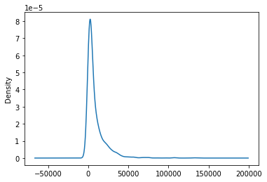

```python
clean_data.favorite_count.plot(kind = 'density')
```

No, it isn't

### Question 2. Which dog is the most liked?

[figure not shown]

```python
clean_data.groupby('dog_stage')['favorite_count'].count().plot(kind='barh')
plt.title('Most liked dog', fontsize = 14)
plt.xlabel('Number of likes', fontsize = 12)
plt.ylabel('Dog Stages', fontsize = 12)
```

### Distribution for img_num

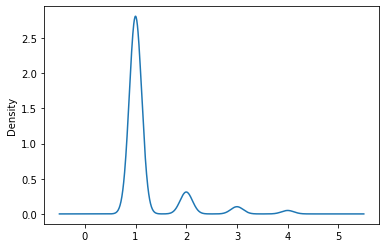

```python
clean_data.img_num.plot(kind = 'density')
```

### Question 3: Which source does the most engagements come from?

```python
clean_data.source.value_counts()
```

```
<a href="http://twitter.com/download/iphone" rel="nofollow">Twitter for iPhone</a>     2030
<a href="http://twitter.com" rel="nofollow">Twitter Web Client</a>                       30
<a href="https://about.twitter.com/products/tweetdeck" rel="nofollow">TweetDeck</a>      11
Name: source, dtype: int64
```

```python
clean_data.source.replace('<a href="http://twitter.com/download/iphone" rel="nofollow">Twitter for iPhone</a>', 'iPhone', inplace= True)
clean_data.source.replace('<a href="http://twitter.com" rel="nofollow">Twitter Web Client</a>', 'Twitter', inplace= True)
clean_data.source.replace('<a href="https://about.twitter.com/products/tweetdeck" rel="nofollow">TweetDeck</a>', 'TweetDeck', inplace= True)
```

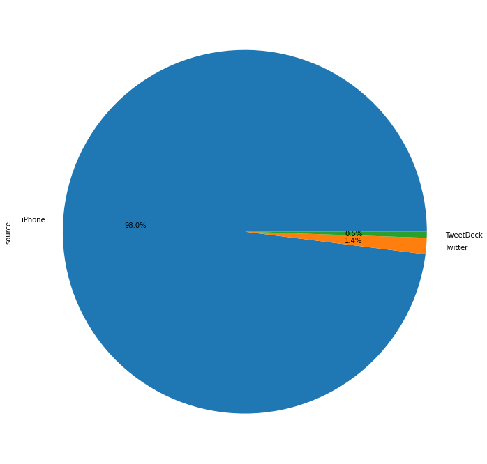

```python
clean_data.source.value_counts().plot(kind = 'pie', autopct='%1.1f%%', figsize = (18, 12))
```